# Workshop 1: `ggplot2` and `dplyr`

### Try yourself

1. Try adding `colour = 'purple'` as an additional argument to `geom_point`, after the mapping argument.
2. Try adding `colour = 'purple'` as an additional argument to `aes` inside `geom_point`. Which is the appropriate spot for colours points purple? This is **setting** an aesthetic.
3. Try mapping the `colour` aesthetic to the `species` column of the `penguins` data.

[figure not shown]

```r
#1.
ggplot(data = pebguins) +
  geom_point(
    mapping = aes(x = flipper_length_mm,
                  y = body_mass_g), colour = 'purple')
```

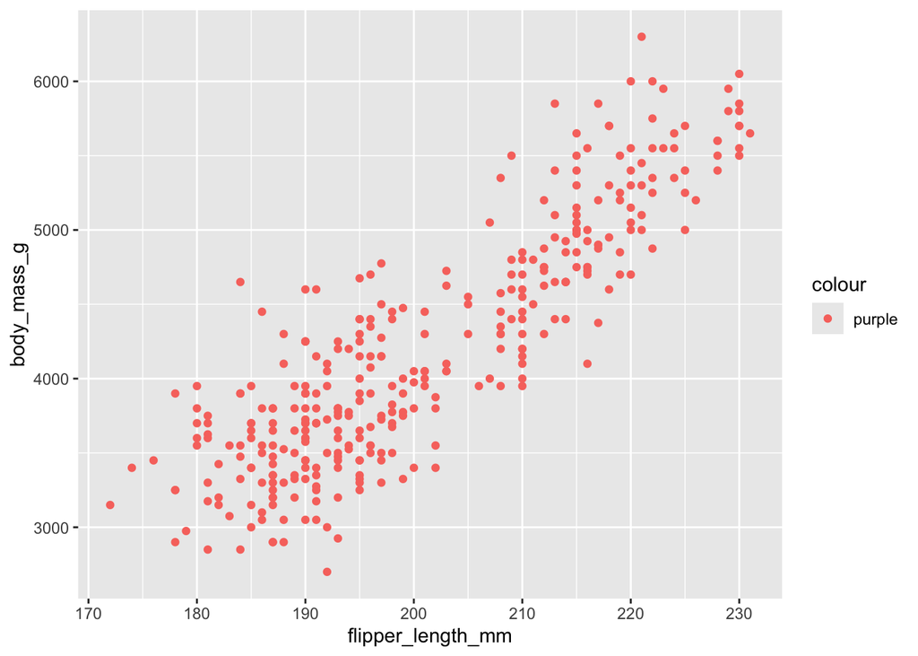

```r
#2.
ggplot(data = penguins) +
  geom_point(
    mapping = aes(x = flipper_length_mm,
                  y = body_mass_g, colour = 'purple'))
```

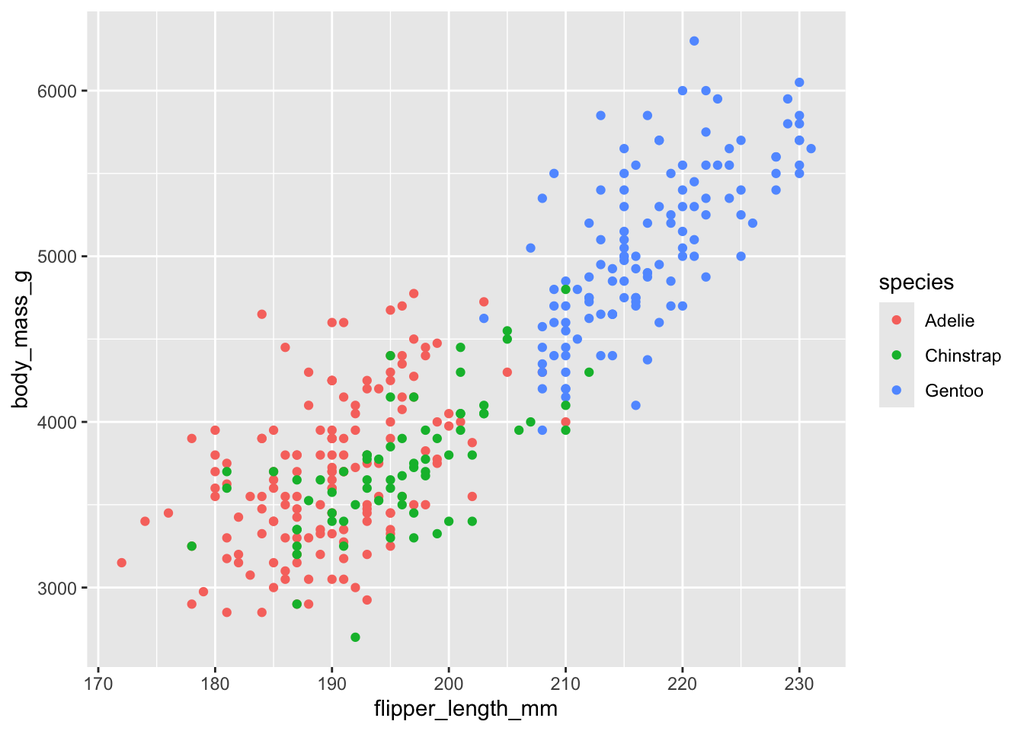

```r
#3
ggplot(data = penguins) +
  geom_point(
    mapping = aes(x = flipper_length_mm,
                  y = body_mass_g, colour = species))
```

You should have noticed that the values in the `flipper_length_mm` and `body_mass_g` are rounded, so that the points appear to be uniformly spaced in some instances. Indeed, it is feasible that there are pairs of points in the data that are identical, so that the points might be placed directly on top of each other. We can’t tell in this plot if this is the case or not, as there is no depth to the chart.

There is two potential ways to fix this:

1. Adding some *jitter* via using `geom_jitter`. This adds some random noise to the x or y values before plotting so we can tell if there is multiple points close to each other.
2. Add some transparency to the points by setting `alpha` (the aesthetic for transparency) to something smaller than 1 (`alpha = 1` is the default, which is opaque. `alpha = 0` is fully transparent).

Both of these methods will allow the *ink density* to reveal where there is more data - areas with more points will appear darker than areas with fewer points.

### Try yourself

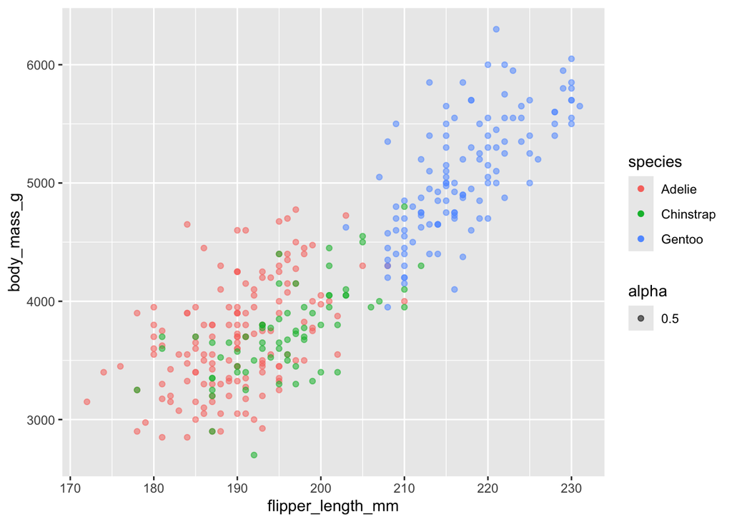

```r
#1
 ggplot(data = penguins, aes(x = flipper_length_mm,
                  y = body_mass_g)) +
  geom_point(aes(colour = species, alpha = 0.5))
```

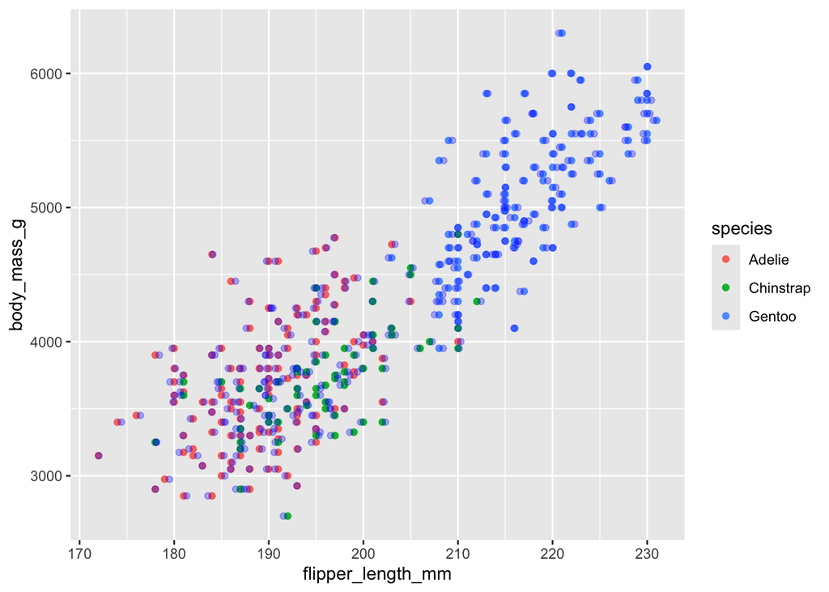

```r
#2
 ggplot(data = penguins, aes(x = flipper_length_mm,
                  y = body_mass_g)) +
  geom_point(aes(colour = species))+
geom_jitter(colour = 'blue',alpha = 0.3, width = 0.5, height = 0.5)
```

1. Implement each of the above methods to assess whether they help in this case.
2. You could try both at once, or try altering the amount of jitter (see the help for `geom_jitter`, or Google!)

In the example above we used just one layer, `geom_point`, but we can add multiple layers if we like. e.g.

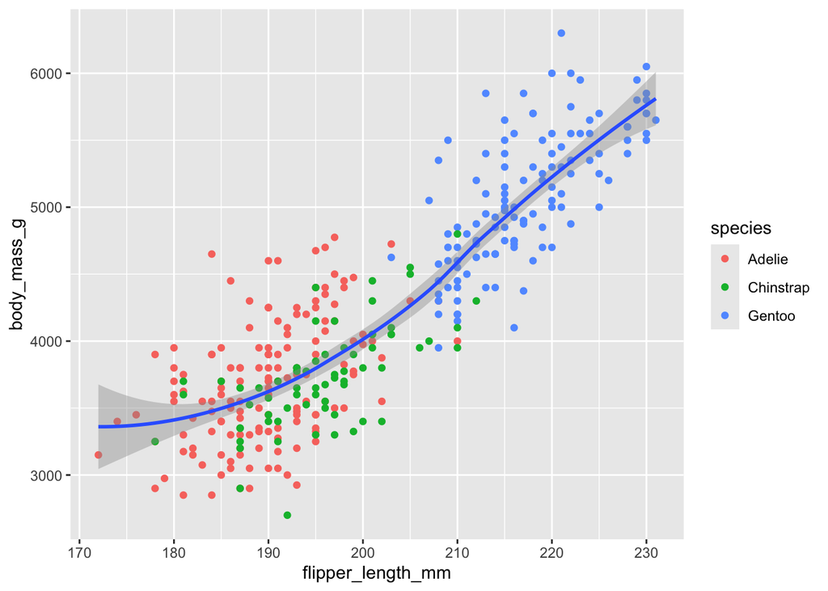

```r
ggplot(data = penguins) +
  geom_point(mapping = aes(x = flipper_length_mm, y = body_mass_g, colour = species)) +
  geom_smooth(mapping = aes(x = flipper_length_mm, y = body_mass_g))
```

Note the repetition here in that the `mapping` is defined twice. We can simplify this by noting that the `ggplot` function also has a `mapping` argument, and any layer without one will inherit this mapping, simplifying the code to:

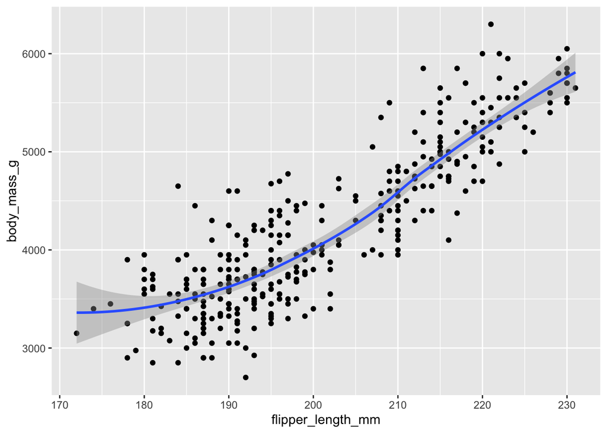

```r
ggplot(data = penguins, mapping = aes(x = flipper_length_mm, y = body_mass_g)) +
  geom_point() +
  geom_smooth()
```

Ofcourse, we can override the mapping if we like, e.g. to map `colour` to `species`.

### Try yourself

1. Add a `mapping` argument to `geom_point()` in the code above to map the colour of points to species.
2. Alternatively, modify the `aes()` function in the `ggplot` bit to map the colour of points and the smooth to species.

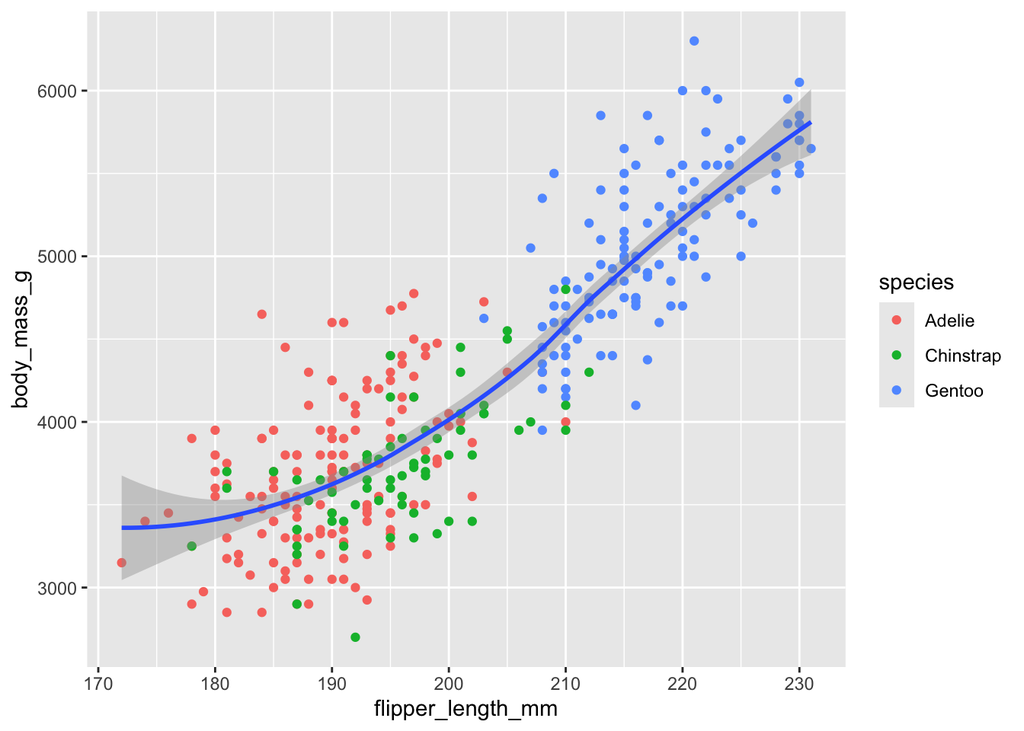

```r
#1
ggplot(data = penguins, mapping = aes(x = flipper_length_mm, y = body_mass_g)) +
  geom_point(mapping = aes(colour = species)) +
  geom_smooth()
```

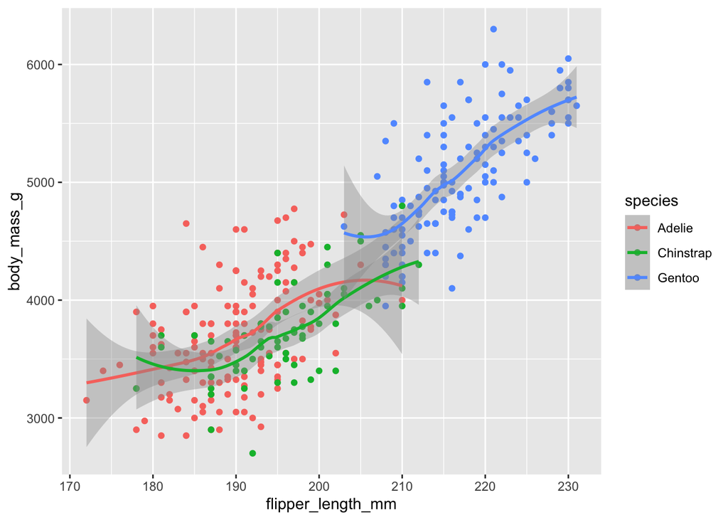

```r
#2
ggplot(data = penguins, mapping = aes(x = flipper_length_mm, y = body_mass_g, colour = species)) +
  geom_point() +
  geom_smooth()
```

Recall that for one-dimensional summaries we can use histograms or density plots, e.g.

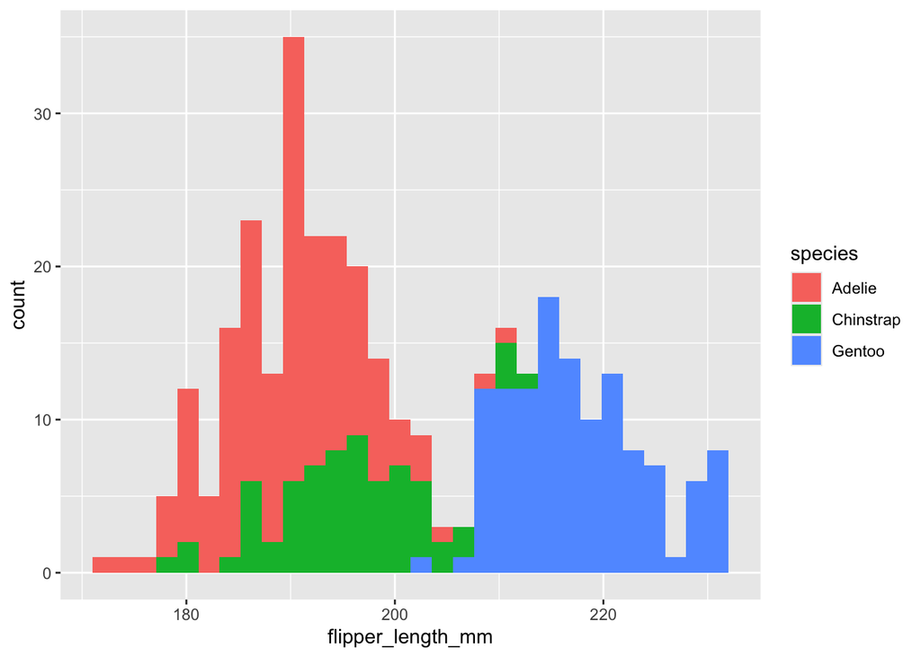

```r
ggplot(data = penguins, mapping = aes(x = flipper_length_mm)) +
  geom_histogram(aes(fill = species))
```

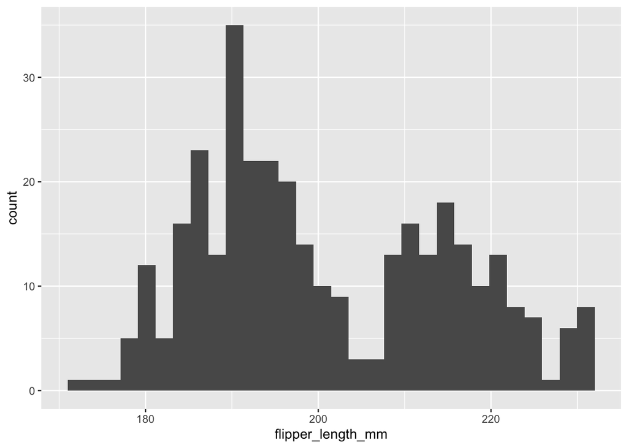

```r
ggplot(data = penguins, mapping = aes(x = flipper_length_mm)) +
  geom_histogram()
```

Obviously the histogram doesn’t require the `y` aesthetic to be mapped, as it is computed by the histogram.

### Try yourself

1. Modify the above to use `geom_density()` instead.
2. Try mapping `colour` or `fill` to species of the density and histogram. You should notice that the histogram stacks (i.e. the second histogram bars start on top of the first), while the densities start at zero.
3. Try altering the histogram coloured by species so the bars don’t stack. Check out the `position` argument to `geom_histogram` for this (Google, or look up help).
4. Have a play with the `adjust` argument of `geom_density`: Values greater than 1 will result in more smoothing, values less than one less smoothing[^2].
5. Switch to using `geom_boxplot()` instead. Note that with boxplots you have the option of mapping the `y` aesthetic to something such as `species` - ofcourse you can still map the `colour` or `fill` as well!

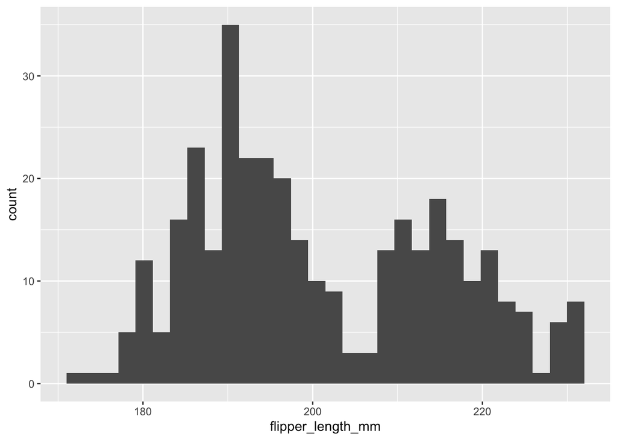

```r
ggplot(data = penguins, mapping = aes(x = flipper_length_mm)) +
  geom_histogram()
```

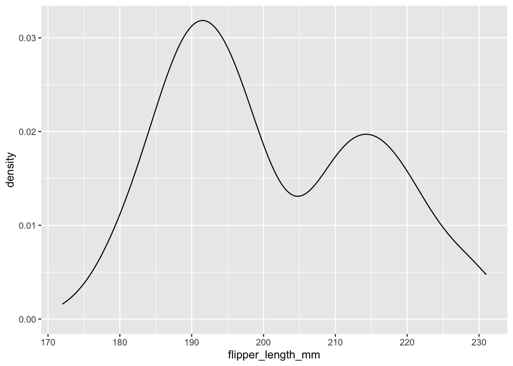

```r
ggplot(data = penguins, mapping = aes(x = flipper_length_mm)) +
  geom_density()
```

Recall that you can label charts using the `labs` command. Remember that the arguments to `labs` are the aesthetics (i.e. `x`, `y`, `colour`, `fill`) in addition to `title`, `subtitle`, `caption`.

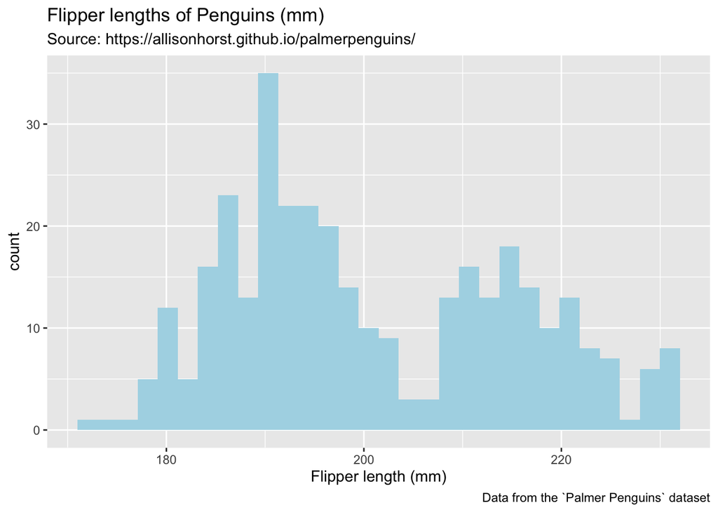

```r
ggplot(data = penguins, mapping = aes(x = flipper_length_mm)) +
  labs(title = "Flipper lengths of Penguins (mm)",
       x = "Flipper length (mm)",
       subtitle = "Source: https://allisonhorst.github.io/palmerpenguins/",
       caption = "Data from the `Palmer Penguins` dataset") +
  geom_histogram(fill= "lightblue", bins = 30)
```

### Try yourself

1. Modify some of your above plots to provide better axis labels, a title and perhaps a caption with the data source or with details of who made the plot (you!)

## Data manipulation with `dplyr`

Recall that `dplyr` is the main package in the `tidyverse` for manipulating data. There are essentially 6 key verbs/functions for you to know about in addition to a bunch of handy shortcuts:

- `filter`: choose rows based on some criteria.
- `arrange`: reorder rows based on some criteria.
- `select`: choose or reorder columns.
- `mutate`: add or modify columns
- `summarise`: reduce a bunch of rows down to a single summary row.
- `group_by`: group the data so that the above operations apply per group.

We start by reading in some data on the number of school students in New Zealand broken down by school, ethnicity and level. The data comes from

https://www.educationcounts.govt.nz/statistics/school-rolls

and is read in using:

```r
roll <- read_csv("http://www.massey.ac.nz/~jcmarsha/data/schools/roll.csv")
roll
```

```
## # A tibble: 66,261 × 4
##    School                  EthnicGroup Level   Students
##    <chr>                   <chr>       <chr>      <dbl>
##  1 3H School International Asian       Year 10        1
##  2 3H School International Asian       Year 7         2
##  3 3H School International European    Year 7         1
##  4 3H School International Pacific     Year 9         1
##  5 3H School International Asian       Year 9         1
##  6 A1 Student Limited      European    Year 10        1
##  7 A1 Student Limited      European    Year 11        1
##  8 A1 Student Limited      European    Year 4         2
##  9 A1 Student Limited      Asian       Year 5         1
## 10 A1 Student Limited      European    Year 5         2
## # ℹ 66,251 more rows
```

You should see there are 66,261 rows for 4 different variables (`School`, `EthnicGroup`, `Level`, `Students`)

We’ll start by using `filter` to select rows that satisfy one or more conditions. This is useful for quickly obtaining subsets of interest (indeed, the `subset` command from base R works similarly).

This next code block filters all rows where `EthnicGroup` is set to `Māori`. Notice the use of two equals for ‘is equal to’

```r
filter(roll, EthnicGroup == "Māori")
```

```
## # A tibble: 16,798 × 4
##    School              EthnicGroup Level   Students
##    <chr>               <chr>       <chr>      <dbl>
##  1 ACG Parnell College Māori       Year 11        1
##  2 ACG Parnell College Māori       Year 13        1
##  3 ACG Parnell College Māori       Year 7         2
##  4 ACG Parnell College Māori       Year 8         1
##  5 ACG Strathallan     Māori       Year 10        9
##  6 ACG Strathallan     Māori       Year 11        5
##  7 ACG Strathallan     Māori       Year 12        5
##  8 ACG Strathallan     Māori       Year 13        2
##  9 ACG Strathallan     Māori       Year 6         1
## 10 ACG Strathallan     Māori       Year 7         4
## # ℹ 16,788 more rows
```

```r
filter(roll, Level == "Year 7")
```

```
## # A tibble: 7,086 × 4
##    School                  EthnicGroup              Level  Students
##    <chr>                   <chr>                    <chr>     <dbl>
##  1 3H School International Asian                    Year 7        2
##  2 3H School International European                 Year 7        1
##  3 A1 Student Limited      European                 Year 7        5
##  4 ACG Parnell College     Māori                    Year 7        2
##  5 ACG Parnell College     Asian                    Year 7      152
##  6 ACG Parnell College     MELAA                    Year 7        1
##  7 ACG Parnell College     Other                    Year 7        2
##  8 ACG Parnell College     European                 Year 7       16
##  9 ACG Parnell College     International fee paying Year 7        2
## 10 ACG Strathallan         Māori                    Year 7        4
## # ℹ 7,076 more rows
```

### A note about macrons

The above line of code for filtering our `roll` data by `EthnicGroup` utilises a macron in the word “Māori”. On many devices this can be a bit tricky to type in! In most systems (Mac, Windows, Linux) you can do this by installing the Māori keyboard setup. Another way is to use copy and paste. e.g. if we do something like:

```r
count(roll, EthnicGroup)
```

```
## # A tibble: 7 × 2
##   EthnicGroup                  n
##   <chr>                    <int>
## 1 Asian                    11448
## 2 European                 15696
## 3 International fee paying  1520
## 4 MELAA                     7623
## 5 Māori                    16798
## 6 Other                     3291
## 7 Pacific                   9885
```

this shows us how many rows there are of each entry in `EthnicGroup`. We can then copy and paste “Māori” entry into our code. As macrons are super important in te reo and many other languages, we will try and use them wherever we can.

More than one row may be selected by separating different conditions with commas (for AND) or the vertical pipe symbol (for OR). e.g. compare the following:

```r
filter(roll, EthnicGroup == "Māori", Level == "Year 1")
```

```
## # A tibble: 1,795 × 4
##    School                      EthnicGroup Level  Students
##    <chr>                       <chr>       <chr>     <dbl>
##  1 Abbotsford School           Māori       Year 1        6
##  2 Aberdeen School             Māori       Year 1       32
##  3 Addington Te Kura Taumatua  Māori       Year 1        9
##  4 Adventure School            Māori       Year 1        3
##  5 Ahipara School              Māori       Year 1       24
##  6 Ahuroa School               Māori       Year 1        4
##  7 Ahutoetoe School            Māori       Year 1        1
##  8 Aidanfield Christian School Māori       Year 1        3
##  9 Aka Aka School              Māori       Year 1        6
## 10 Akaroa Area School          Māori       Year 1        1
## # ℹ 1,785 more rows
```

```r
filter(roll, EthnicGroup == "Māori" | Level == "Year 1")
```

```
## # A tibble: 21,976 × 4
##    School              EthnicGroup Level   Students
##    <chr>               <chr>       <chr>      <dbl>
##  1 ACG Parnell College Asian       Year 1        27
##  2 ACG Parnell College European    Year 1         2
##  3 ACG Parnell College Māori       Year 11        1
##  4 ACG Parnell College Māori       Year 13        1
##  5 ACG Parnell College Māori       Year 7         2
##  6 ACG Parnell College Māori       Year 8         1
##  7 ACG Strathallan     Pacific     Year 1         3
##  8 ACG Strathallan     Asian       Year 1        47
##  9 ACG Strathallan     Other       Year 1         1
## 10 ACG Strathallan     European    Year 1         4
## # ℹ 21,966 more rows
```

A helper function for ‘one of these options’ is `%in%`. e.g. these two are equivalent:

```r
filter(roll, Level == "Year 1" | Level == "Year 2" | Level == "Year 3" | Level == "Year 4")
```

```
## # A tibble: 27,989 × 4
##    School              EthnicGroup Level  Students
##    <chr>               <chr>       <chr>     <dbl>
##  1 A1 Student Limited  European    Year 4        2
##  2 ACG Parnell College Asian       Year 1       27
##  3 ACG Parnell College European    Year 1        2
##  4 ACG Parnell College Asian       Year 2       48
##  5 ACG Parnell College MELAA       Year 2        1
##  6 ACG Parnell College European    Year 2        3
##  7 ACG Parnell College Pacific     Year 3        1
##  8 ACG Parnell College Asian       Year 3       35
##  9 ACG Parnell College Other       Year 3        1
## 10 ACG Parnell College European    Year 3        5
## # ℹ 27,979 more rows
```

```r
filter(roll, Level %in% c("Year 1", "Year 2", "Year 3", "Year 4"))
```

```
## # A tibble: 27,989 × 4
##    School              EthnicGroup Level  Students
##    <chr>               <chr>       <chr>     <dbl>
##  1 A1 Student Limited  European    Year 4        2
##  2 ACG Parnell College Asian       Year 1       27
##  3 ACG Parnell College European    Year 1        2
##  4 ACG Parnell College Asian       Year 2       48
##  5 ACG Parnell College MELAA       Year 2        1
##  6 ACG Parnell College European    Year 2        3
##  7 ACG Parnell College Pacific     Year 3        1
##  8 ACG Parnell College Asian       Year 3       35
##  9 ACG Parnell College Other       Year 3        1
## 10 ACG Parnell College European    Year 3        5
## # ℹ 27,979 more rows
```

```r
#1
filter(roll, School == "Queen Elizabeth College", Level == "Year 9")
```

```
## # A tibble: 3 × 4
##   School                  EthnicGroup Level  Students
##   <chr>                   <chr>       <chr>     <dbl>
## 1 Queen Elizabeth College Māori       Year 9       40
## 2 Queen Elizabeth College Pacific     Year 9        7
## 3 Queen Elizabeth College European    Year 9       14
```

```r
#2
filter(roll, Level == "Year 9", Students > 100)
```

```
## # A tibble: 188 × 4
##    School                         EthnicGroup Level  Students
##    <chr>                          <chr>       <chr>     <dbl>
##  1 ACG Parnell College            Asian       Year 9      158
##  2 Albany Junior High School      European    Year 9      127
##  3 Aorere College                 Pacific     Year 9      160
##  4 Aorere College                 Asian       Year 9      104
##  5 Aotea College                  European    Year 9      156
##  6 Ashburton College              European    Year 9      163
##  7 Auckland Girls' Grammar School Pacific     Year 9      133
##  8 Auckland Grammar School        Asian       Year 9      237
##  9 Auckland Grammar School        European    Year 9      142
## 10 Avondale College               Pacific     Year 9      139
## # ℹ 178 more rows
```

```r
#3
filter(roll, str_starts(School, "G"))
```

```
## # A tibble: 2,102 × 4
##    School         EthnicGroup Level  Students
##    <chr>          <chr>       <chr>     <dbl>
##  1 Galatea School Māori       Year 1       13
##  2 Galatea School Pacific     Year 1        1
##  3 Galatea School European    Year 1        4
##  4 Galatea School Māori       Year 2       12
##  5 Galatea School Asian       Year 2        1
##  6 Galatea School Other       Year 2        1
##  7 Galatea School European    Year 2        9
##  8 Galatea School Māori       Year 3        8
##  9 Galatea School Asian       Year 3        1
## 10 Galatea School European    Year 3        7
## # ℹ 2,092 more rows
```

### Try yourself:

You can `arrange` (sort) row output based on the values in each column, and can arrange by more than one column at once. The first column specified will be sorted first, and then all entries that are the same on that column will then be sorted by the second and multiple columns.

You can use `desc()` to sort in descending order.

```r
arrange(roll, EthnicGroup, Level)
```

```
## # A tibble: 66,261 × 4
##    School                     EthnicGroup Level  Students
##    <chr>                      <chr>       <chr>     <dbl>
##  1 ACG Parnell College        Asian       Year 1       27
##  2 ACG Strathallan            Asian       Year 1       47
##  3 ACG Sunderland             Asian       Year 1       31
##  4 ACG Tauranga               Asian       Year 1        3
##  5 AGE School                 Asian       Year 1        1
##  6 Abbotsford School          Asian       Year 1        1
##  7 Aberdeen School            Asian       Year 1       17
##  8 Addington Te Kura Taumatua Asian       Year 1       21
##  9 Adventure School           Asian       Year 1       12
## 10 Ahuroa School              Asian       Year 1        1
## # ℹ 66,251 more rows
```

```r
arrange(roll, desc(Students))
```

```
## # A tibble: 66,261 × 4
##    School                                 EthnicGroup Level   Students
##    <chr>                                  <chr>       <chr>      <dbl>
##  1 Te Aho o Te Kura Pounamu               European    Year 12      800
##  2 Te Puna Wai o Waipapa - Hagley College European    Year 13      782
##  3 Te Aho o Te Kura Pounamu               European    Year 15      758
##  4 Te Aho o Te Kura Pounamu               European    Year 13      733
##  5 Te Aho o Te Kura Pounamu               European    Year 11      568
##  6 Te Aho o Te Kura Pounamu               European    Year 14      553
##  7 Te Aho o Te Kura Pounamu               Māori       Year 15      468
##  8 Te Aho o Te Kura Pounamu               Māori       Year 11      449
##  9 Te Aho o Te Kura Pounamu               Māori       Year 12      396
## 10 Macleans College                       Asian       Year 10      372
## # ℹ 66,251 more rows
```

```r
#1
arrange(roll, desc(Students))
```

```
## # A tibble: 66,261 × 4
##    School                                 EthnicGroup Level   Students
##    <chr>                                  <chr>       <chr>      <dbl>
##  1 Te Aho o Te Kura Pounamu               European    Year 12      800
##  2 Te Puna Wai o Waipapa - Hagley College European    Year 13      782
##  3 Te Aho o Te Kura Pounamu               European    Year 15      758
##  4 Te Aho o Te Kura Pounamu               European    Year 13      733
##  5 Te Aho o Te Kura Pounamu               European    Year 11      568
##  6 Te Aho o Te Kura Pounamu               European    Year 14      553
##  7 Te Aho o Te Kura Pounamu               Māori       Year 15      468
##  8 Te Aho o Te Kura Pounamu               Māori       Year 11      449
##  9 Te Aho o Te Kura Pounamu               Māori       Year 12      396
## 10 Macleans College                       Asian       Year 10      372
## # ℹ 66,251 more rows
```

```r
#2
roll |>
  filter(EthnicGroup == "Pacific") |>
  arrange(desc(Students))
```

```
## # A tibble: 9,885 × 4
##    School                  EthnicGroup Level   Students
##    <chr>                   <chr>       <chr>      <dbl>
##  1 Kedgley Intermediate    Pacific     Year 7       289
##  2 Manurewa High School    Pacific     Year 9       259
##  3 Manurewa High School    Pacific     Year 11      245
##  4 Kedgley Intermediate    Pacific     Year 8       237
##  5 Manurewa Intermediate   Pacific     Year 8       226
##  6 Manurewa Intermediate   Pacific     Year 7       225
##  7 Manurewa High School    Pacific     Year 10      219
##  8 Papatoetoe Intermediate Pacific     Year 8       192
##  9 Manurewa High School    Pacific     Year 12      190
## 10 Papatoetoe Intermediate Pacific     Year 7       174
## # ℹ 9,875 more rows
```

```r
#3
roll |>
  filter(EthnicGroup == "International fee paying") |>
  arrange(desc(Students))
```

```
## # A tibble: 1,520 × 4
##    School                               EthnicGroup              Level  Students
##    <chr>                                <chr>                    <chr>     <dbl>
##  1 UP International College New Zealand International fee paying Year …       71
##  2 Macleans College                     International fee paying Year …       51
##  3 Rangitoto College                    International fee paying Year …       42
##  4 Rangitoto College                    International fee paying Year …       41
##  5 Avondale College                     International fee paying Year …       39
##  6 Macleans College                     International fee paying Year …       36
##  7 Waimea College                       International fee paying Year …       35
##  8 Takapuna Grammar School              International fee paying Year …       32
##  9 Burnside High School                 International fee paying Year …       31
## 10 Rangitoto College                    International fee paying Year …       31
## # ℹ 1,510 more rows
```

### Try yourself

1. Arrange the roll rows by number of students.
2. Find all rows where the ethnicity is Pacific, arranging them by decreasing number of students. (Hint: First filter down to Pacific students, then arrange)
3. Which school has the highest number of International fee paying students at Year 13? (Hint: ‘International fee paying’ is an option for `EthnicGroup`) == UP International College New Zealand